[OHI-Northeast](http://www.ohi-northeast.org/) | [OHI Science](http://ohi-science.org) | [Citation policy](http://ohi-science.org/citation-policy/)

# OHI-Northeast: Fisheries access data layer

Compiled on Mon Nov 25 10:32:39 2019 by afflerbach

```r
knitr::opts_chunk$set(fig.width = 6, fig.height = 4, fig.path = 'figs/',
                      message = FALSE, warning = FALSE)

source('~/github/ne-prep/src/R/common.R')  ### an OHINE specific version of common.R

dir_git <- '~/github/ne-prep'
dir_anx <- file.path(dir_M, 'git-annex/neprep')

#libraries
library(tidyverse)
library(readxl)
```

# Summary

Fisheries access layer is derived from NOAA FSSI data.

# Data Source

## [NOAA Fish Stock Sustainability Index](https://www.fisheries.noaa.gov/national/population-assessments/status-us-fisheries)

**Downloaded**: Emailed to Jamie Afflerbach on July 29, 2019 by Karen Greene (NOAA)

**Native data resolution**: Stock level

**Time range**: 2005-2018

**Format**: Tabular ***

# Analysis

## Load FSSI data

The files were emailed to me individually by year. Unfortunately they are not consistent through time either. But it seems like 2005 - 2010 are in the same format… and have the Table A as the first row.

```r
all_files <- list.files(file.path(dir_anx, "_raw_data/NOAA_FSSI"), full.names = T, pattern = ".xls")
```

```r
early_files <- all_files[str_detect(all_files, paste(c("2005","2006","2007", "2008", "2009", "2010"), collapse = '|'))]

#it looks like 2005-2010 have the same structure so use a loop to iterate through

clean_func <- function(filepath){

  year <- substr(filepath, 58, 61)

  d <- read_excel(filepath, skip = 1, col_names = TRUE, sheet = 1) %>%
    filter(Jurisdiction %in% c("NEFMC", "NEFMC / MAFMC")) %>% #filter for just NE managed stocks
  select(1:3,ncol(.)) %>%
    rename(FMP = 1, stock = 2, Jurisdiction = 3, FSSI = 4) %>% #get the first 3 and the very last column
    mutate(year = as.numeric(year))

return(d)

}

#use map_df to apply the function to all files and return as single combined dataframe
early_df <- map_df(early_files, clean_func)
```

```r
late_files <- all_files[str_detect(all_files, paste(c("2011", "2012", "2013", "2014", "2015", "2016", "2017"), collapse = '|'))]

clean_func <- function(filepath){

  year <- substr(filepath, 58, 61)

  if (year == 2014) { #2014 has an extra column on the end after FSSI

  d <- read_excel(filepath, col_names = TRUE, sheet = 1) %>% #difference here from early files is we don't skip first line
    filter(Jurisdiction %in% c("NEFMC", "NEFMC / MAFMC")) %>% #filter for just NE managed stocks
  select(1:3,ncol(.)-1) %>% #get the first 3 and the very last column
    rename(Jurisdiction = 1, FMP = 2, stock = 3, FSSI = 4) %>%
    mutate(year = as.numeric(year))

  }else{

  d <- read_excel(filepath, col_names = TRUE, sheet = 1) %>% #difference here from early files is we don't skip first line
    filter(Jurisdiction %in% c("NEFMC", "NEFMC / MAFMC")) %>% #filter for just NE managed stocks
  select(1:3,ncol(.)) %>% #get the first 3 and the very last column
    rename(Jurisdiction = 1,  FMP = 2, stock = 3, FSSI = 4) %>%
    mutate(year = as.numeric(year))
  }
return(d)

}

#use map_df to apply the function to all files and return as single combined dataframe
late_df <- map_df(late_files, clean_func)
```

Combine old and newer dataframes

```r
fssi_data <- early_df %>%
  bind_rows(late_df)
```

Now link each stock to the region where it is found. We can use the lookup table created in `ne-prep/prep/fis`. This is split into two columns, `stock_assessment_species_name` and `stock_assessment_species_location`. We can use these to link by separating the `stock` column.

```r
fish_sp <- read_csv("~/github/ne-prep/prep/fis/data/assessed_species_lookup_table.csv") %>%
  select(stock = stock_assessment_species_name,
         location = stock_assessment_species_location,
         rgn_id,
         source) %>%
  distinct()
DT::datatable(fish_sp)
```

|  | stock | location | rgn_id | source |
| --- | --- | --- | --- | --- |
| 1 | atlantic cod | Georges Bank | 1 | NMFS |
| 2 | atlantic cod | Georges Bank | 2 | NMFS |
| 3 | atlantic cod | Georges Bank | 3 | NMFS |
| 4 | atlantic cod | Georges Bank | 4 | NMFS |
| 5 | atlantic cod | Georges Bank | 5 | NMFS |
| 6 | atlantic cod | Georges Bank | 7 | NMFS |
| 7 | atlantic cod | Georges Bank | 8 | NMFS |
| 8 | atlantic cod | Georges Bank | 10 | NMFS |
| 9 | atlantic cod | Georges Bank | 11 | NMFS |
| 10 | atlantic cod | Georges Bank | 12 | NMFS |

[output cut: 554 more lines]

## Clean

- clean up some names and locations from the FSSI data to match with `fish_sp`.

The location for silver hake and red hake in 2005-2007 in the FSSI data is listed as “Southern New England / Mid-Atlantic” but in the NMFS stock assessment data, the southern stock is labeled as “Southern Georges Bank / Mid-Atlantic”. Those changes are made here

```r
fssi_data_clean <- fssi_data %>%
  separate(stock, into = c("stock", "location"), sep = " - ",) %>%
  mutate(stock = tolower(stock), #change species name to lower to better join
         location = str_replace_all(location, " \\*", ""),
         location = str_replace_all(location, "\\*", "")) %>%
  mutate(stock = case_when(
    stock == "atlantic sea scallop" ~ "sea scallop",
    stock == "cod" ~ "atlantic cod",
    stock == "windowpane flounder" ~ "windowpane",
    stock == "redfish" ~ "acadian redfish",
    stock == "deep-sea red crab" ~ "red deepsea crab",
    stock == "monkfish" ~ "goosefish",
    TRUE ~ as.character(stock)
  ),
  location = case_when(
    location %in% c("Southern New England /Middle Atlantic",
                    "Southern Georges Bank / Middle Atlantic",
                    "Southern New England/Middle Atlantic") ~ "Southern New England / Mid-Atlantic",
    location %in% c("Cape Cod /    Gulf of Maine",
                    "Cape Cod /    Gulf Of Maine") ~ "Cape Cod / Gulf of Maine",
    location == "Gulf Of Maine" ~ "Gulf of Maine",
    location == "Gulf Of Maine / Georges Bank" ~ "Gulf of Maine / Georges Bank",
    location %in% c("Gulf Of Maine / Northern Georges Bank",
                    "Gulf Of Maine  / Northern Georges Bank",
                    "Gulf of Maine  / Northern Georges Bank") ~ "Gulf of Maine / Northern Georges Bank",
    location == "Southern New England / Middle Atlantic" ~ "Southern New England / Mid-Atlantic",
    TRUE ~ as.character(location)
  ),
  location = case_when(
    stock %in% c("red hake", "silver hake") & location == "Southern New England / Mid-Atlantic" ~ "Southern Georges Bank / Mid-Atlantic",
    stock == "goosefish" & location == "South" ~ "Southern Georges Bank / Mid-Atlantic",
    stock == "goosefish" & location == "North" ~ "Gulf of Maine / Northern Georges Bank",
    TRUE ~ as.character(location))) %>%
  left_join(fish_sp, by = c("stock", "location"))
```

Some still don’t match because they are missing locations from the FSSI data. For these we join on stock only. These are all from 2005-2007

```r
fssi_data_clean2 <- fssi_data_clean %>%
  filter(is.na(location)) %>%
  left_join(fish_sp, by = "stock") %>%
  select(FMP, stock, location = location.y, Jurisdiction, FSSI, year, source = source.y, rgn_id = rgn_id.y)
```

Join back to `fssi_data_clean` and just have to fix offshore hake which isn’t in the `fish_sp` but all years >2008 have it identified as Northwestern Atlantic Coast. Need to fill out `rgn_id` where they are NA.

```r
fssi <- fssi_data_clean %>%
  filter(!is.na(location)) %>%
  bind_rows(fssi_data_clean2) %>%
  mutate(location = ifelse(stock == "offshore hake", "Northwestern Atlantic Coast", location))


a <- filter(fssi, is.na(rgn_id))
DT::datatable(a)
```

|  | FMP | stock | location | Jurisdiction | FSSI | year | rgn_id | source |
| --- | --- | --- | --- | --- | --- | --- | --- | --- |
| 1 | Northeast Multispecies | offshore hake | Northwestern Atlantic Coast | NEFMC | 1.5 | 2008 |  |  |
| 2 | Northeast Skate Complex | rosette skate | Southern New England / Mid-Atlantic | NEFMC | 4 | 2008 |  | NMFS |
| 3 | Northeast Multispecies | offshore hake | Northwestern Atlantic Coast | NEFMC | 1.5 | 2009 |  |  |
| 4 | Northeast Skate Complex | rosette skate | Southern New England / Mid-Atlantic | NEFMC | 4 | 2009 |  | NMFS |
| 5 | Northeast Multispecies | offshore hake | Northwestern Atlantic Coast | NEFMC | 1.5 | 2010 |  |  |
| 6 | Northeast Skate Complex | rosette skate | Southern New England / Mid-Atlantic | NEFMC | 4 | 2010 |  | NMFS |
| 7 | Northeast Multispecies | offshore hake | Northwestern Atlantic Coast | NEFMC | 0 | 2013 |  |  |
| 8 | Northeast Skate Complex | rosette skate | Southern New England / Mid-Atlantic | NEFMC | 3 | 2013 |  | NMFS |
| 9 | Northeast Multispecies | offshore hake | Northwestern Atlantic Coast | NEFMC | 0 | 2014 |  |  |
| 10 | Northeast Skate Complex | rosette skate | Southern New England / Mid-Atlantic | NEFMC | 4 | 2014 |  | NMFS |

[output cut: 16 more lines]

We are only missing `rgn_id` for offshore hake and rosette skate. We will use the location identifier for these two species, and the associated `rgn_ids` to fill in.

```r
missing_rgns <- fssi %>%
  filter(location %in% c("Northwestern Atlantic Coast", "Southern New England / Mid-Atlantic")) %>%
  select(location, rgn_id) %>%
  filter(!is.na(rgn_id)) %>%
  distinct()
DT::datatable(missing_rgns)
```

|  | location | rgn_id |
| --- | --- | --- |
| 1 | Southern New England / Mid-Atlantic | 1 |
| 2 | Southern New England / Mid-Atlantic | 2 |
| 3 | Southern New England / Mid-Atlantic | 4 |
| 4 | Southern New England / Mid-Atlantic | 5 |
| 5 | Southern New England / Mid-Atlantic | 8 |
| 6 | Southern New England / Mid-Atlantic | 10 |
| 7 | Southern New England / Mid-Atlantic | 11 |
| 8 | Southern New England / Mid-Atlantic | 12 |
| 9 | Southern New England / Mid-Atlantic | 3 |
| 10 | Southern New England / Mid-Atlantic | 7 |

[output cut: 12 more lines]

Now join these region ids back to the rosette skate and offshore hake species.

```r
b <- a %>% left_join(missing_rgns, by = "location")%>%
  select(FMP, stock, location, Jurisdiction, FSSI, year, rgn_id = rgn_id.y)
```

Now create complete FSSI dataset for use in our layer

```r
fssi_full <- fssi %>%
  filter(!is.na(rgn_id)) %>%
  bind_rows(b) %>%
  mutate(stock_location = paste0(stock, " ", location)) %>%
  left_join(rgn_data) %>%
  mutate(rgn_name = ifelse(rgn_id == 12, "Northeast", rgn_name)) %>%
  select(-area_km2, -state_abv, -state, -state_name)

write_csv(fssi_full, "data/fssi_scores.csv")
```

## Visualize

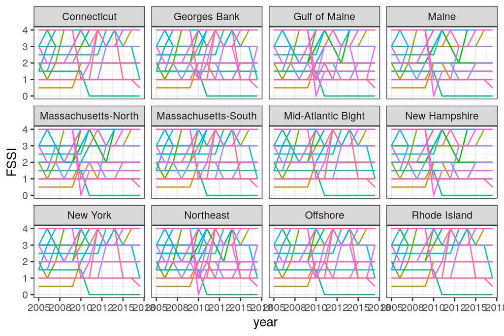

```r
ggplot(fssi_full, aes(x = year, y = FSSI, color = stock_location)) +
  geom_line() +
  facet_wrap(~rgn_name) +
  theme_bw() +
  theme(legend.position = "none")
```

Just look at stocks over time

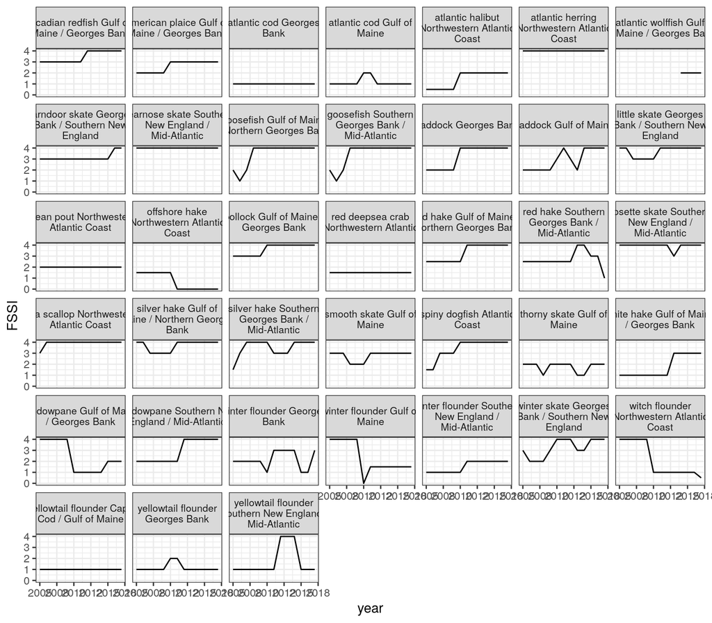

```r
ggplot(fssi_full, aes(x = year, y = FSSI)) +
  geom_line() +
  theme_bw() +
  facet_wrap(~stock_location, labeller = labeller(stock_location = label_wrap_gen(width = 25))) +
  theme(strip.text.x = element_text(size = 8))
```

How many stocks per region?

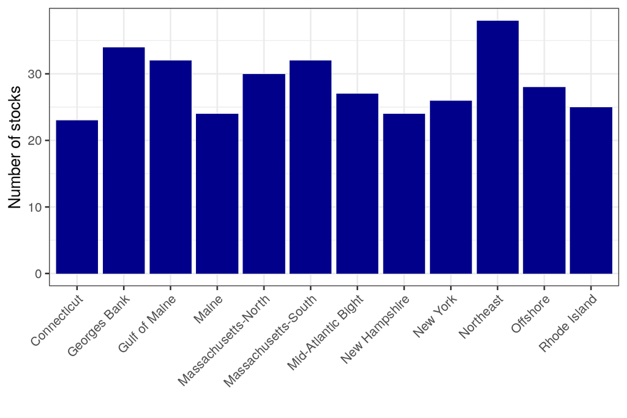

```r
ggplot(fssi_full %>%
         select(rgn_name, stock_location) %>% distinct()) +
  geom_bar(aes(x = rgn_name), fill = 'darkblue') +
  theme_bw() +
  theme(axis.text.x = element_text(angle = 45, hjust = 1)) +
  labs(x = "", y = 'Number of stocks')
```

# Translate to score

The FSSI scores range from 0 - 4 with 4 being the target. So we want to divide all scores by 4 to get a value between 0 and 1. Then take the average by region and year

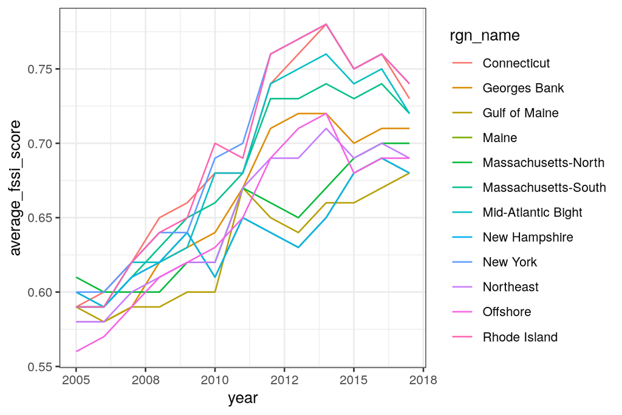

```r
fssi_scaled <- fssi_full %>%
  mutate(scores = FSSI/4) %>%
  group_by(rgn_id, rgn_name, year) %>%
  summarize(average_fssi_score = round(mean(scores), digits = 2)) %>%
  ungroup()

write_csv(fssi_scaled, "data/avg_fssi_score_per_region_over_time.csv")

ggplot(fssi_scaled, aes(x = year, y = average_fssi_score, color = rgn_name)) +
  geom_line() +
  theme_bw()
```

# Save to toolbox

Even though we have data for the 4 offshore regions, the RAO goal is only calculated for coastal regions so we replace scores for rgn_id 1 through 4 with NA

```r
fssi_layer <- fssi_scaled %>%
  mutate(score = ifelse(rgn_id %in% c(1:4), NA, average_fssi_score)) %>%
  select(year, rgn_id, score)

write_csv(fssi_layer, "~/github/ne-scores/region/layers/rao_fssi.csv")
```